# Raporcik_PR08

Grzegorz Zbrzeżny

19 01 2022

W raporcie przeprowadzam analizę zbioru danych odnośnie wyniku zadowolenia mieszkańców danych państw z życia pod kątem różnych aspektów

# 1 Rodzaje zmiennych

- Overall.rank - miejsce w rankingu danego kraju pod względem wyniku ogólnego zadowolenia mieszkańców, nie będę przeprowadzał dokładniejszej analizy wyników, gdyż jest to po prostu wektor składający się z wartości od 1 do ilości badanych krajów
- Country.or.region - kraj, bądź region, do którego on należy, również nie będę przeprowadzał dokładniejszej analizy, gdyż to po prostu lista krajów.
- Score - średnia odpowiedź mieszkańcóW danego kraju na pytanie “Jak ocenia Pan/Pani własne zadowolenie w skali od 0 do 10”
- GDP.per.capita - Jak bardzo PKB na mieszkańca w kraju wpływa na wynik zadowolenia
- Social.support - Jak bardzo pomoc socjalna w kraju wpływa na wynik zadowolenia
- Healthy.life.expectancy - Jak bardzo oczekiwana długość życia w kraju wpływa na wynik zadowolenia
- Freedom.to.make.life.choices - Jak bardzo możliwość podejmowania wolnych wyboróW w kraju wpływa na wynik zadowolenia
- Generosity - Jak bardzo ogólnie pojęta szczodrość obecna w kraju wpływa na wynik zadowolenia
- Perceptions.of.corruption - Jak bardzo postrzeganie korupcji w rządzie kraju wpływa na wynik zadowolenia

# 2 Tabela podsumowująca

|  | Typ | iloscWierszy | iloscNA | iloscUnikalnych |
| --- | --- | --- | --- | --- |
| Overall.rank | integer | 156 | 0 | 156 |
| Country.or.region | character | 156 | 0 | 156 |
| Score | double | 156 | 0 | 155 |
| GDP.per.capita | double | 156 | 0 | 146 |
| Social.support | double | 156 | 0 | 145 |
| Healthy.life.expectancy | double | 156 | 0 | 119 |
| Freedom.to.make.life.choices | double | 156 | 0 | 130 |
| Generosity | double | 156 | 0 | 118 |
| Perceptions.of.corruption | double | 156 | 0 | 113 |

# 3 Dokładniejsza analiza zmiennych

## 3.1 Score

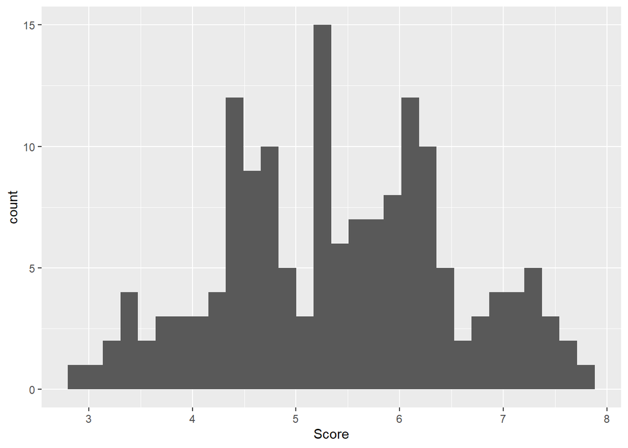

| dane | statisticsVectorScore |
| --- | --- |
| Typ danych | double |
| Ilosc unikalnych | 155 |
| Minimum | 2.853 |
| Maksimum | 7.769 |
| Median | 5.3795 |

Wynik ogólnego zadowolenia utrzymuje się w większości w okolicy połowy maksymalnej ilości punktów i na lewo oraz prawo od tej wartości, ilość krajóW o poszczególnych wynikach maleje co może przypominać rozkład normalny.

## 3.2 GDP.per.capita

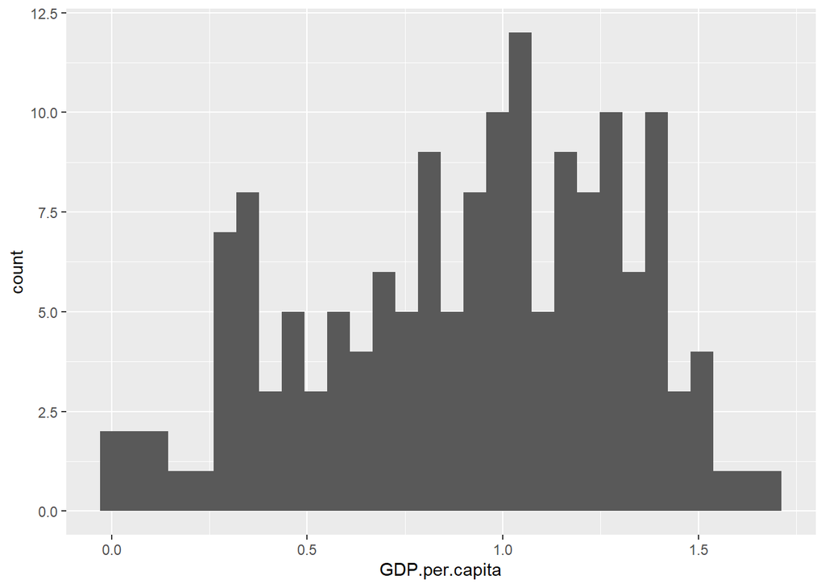

| dane | statisticsVectorGDP.per.capita |
| --- | --- |
| Typ danych | double |
| Ilosc unikalnych | 146 |
| Minimum | 0 |
| Maksimum | 1.684 |
| Median | 0.96 |

Sytuacja podobna jak poprzednio z tym, że najwięcej krajów oscyluje wokół wartości trochę większej niż połowa wartości maksymalnej.

## 3.3 Social.support

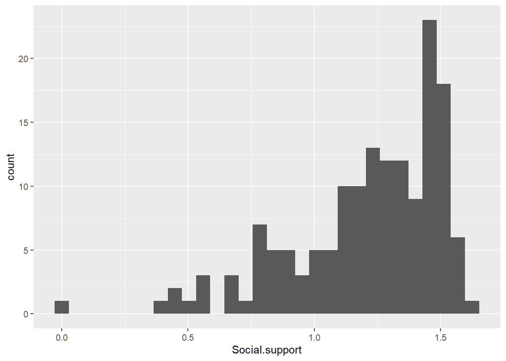

| dane | statisticsVectorSocial.support |
| --- | --- |
| Typ danych | double |
| Ilosc unikalnych | 145 |
| Minimum | 0 |
| Maksimum | 1.624 |
| Median | 1.2715 |

W tym przypadku widać, że w naprawdę wielu krajach jest dobra opieka społeczna.

## 3.4 Healthy.life.expectancy

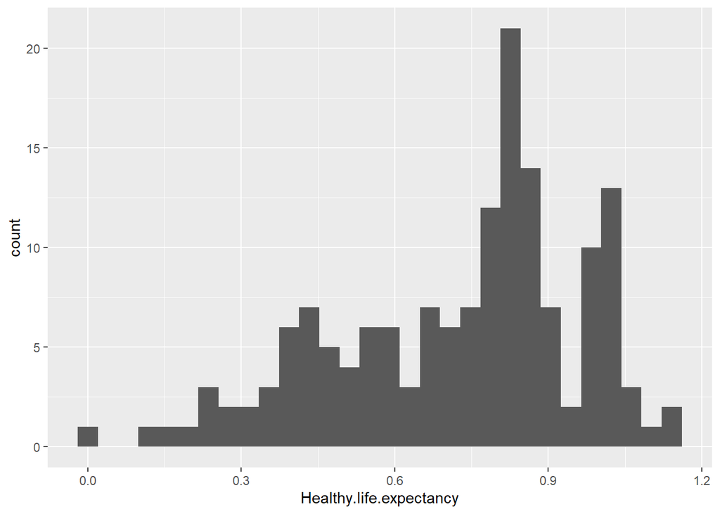

| dane | statisticsVectorHealthy.life.expectancy |
| --- | --- |
| Typ danych | double |
| Ilosc unikalnych | 119 |
| Minimum | 0 |
| Maksimum | 1.141 |
| Median | 0.789 |

Największa wartość oczekiwanej długości życia jest w okolicy 3 kwartyla.

## 3.5 Freedom.to.make.life.choices

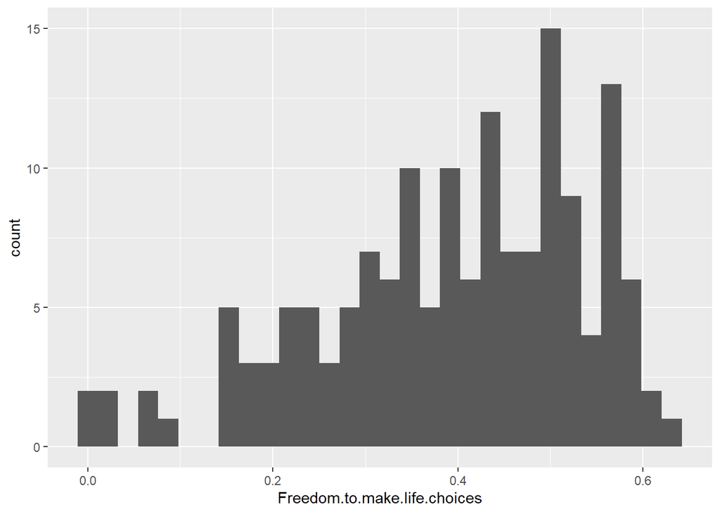

| dane | statisticsVectorFreedom.to.make.life.choices |
| --- | --- |
| Typ danych | double |
| Ilosc unikalnych | 130 |
| Minimum | 0 |
| Maksimum | 0.631 |
| Median | 0.417 |

W znaczącej większości ankietowanych krajóW ludzie uznają możliwość podejmowania samodzielnych decyzji za dość istotną.

## 3.6 Generosity

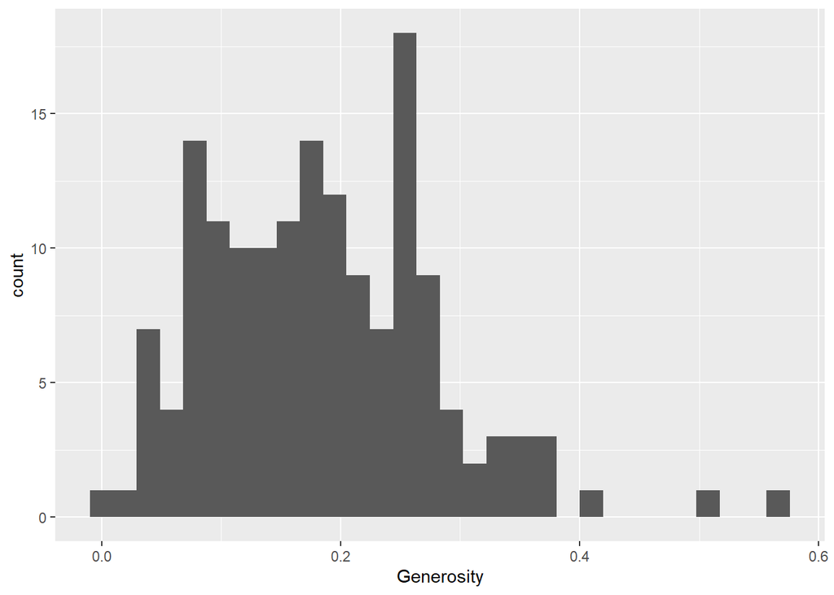

| dane | statisticsVectorGenerosity |
| --- | --- |
| Typ danych | double |
| Ilosc unikalnych | 118 |
| Minimum | 0 |
| Maksimum | 0.566 |
| Median | 0.1775 |

Niestety histogram szczodrości jest podobny do rozkładu normalnego przesuniętego w lewo, co sugeruje, że zdecydowanie nie żyjemy w miłym świecie.

## 3.7 Perceptions.of.corruption

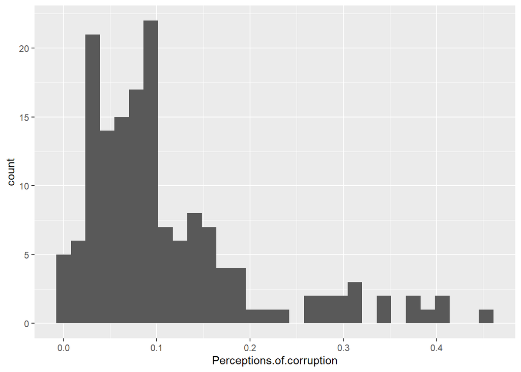

| dane | statisticsVectorPerceptions.of.corruption |
| --- | --- |
| Typ danych | double |
| Ilosc unikalnych | 113 |
| Minimum | 0 |
| Maksimum | 0.453 |
| Median | 0.0855 |

Jak widać ludzie nie przejmują się bardzo korupcją w rządzie, co jednak może wynikać z tego, że rządy starają się ją niewątpliwie ukrywać co znacząco wpływa na postrzeganie problemu przez społeczeństwo

# 4 Analizy zależności

## 4.1 PKB, a długość życia

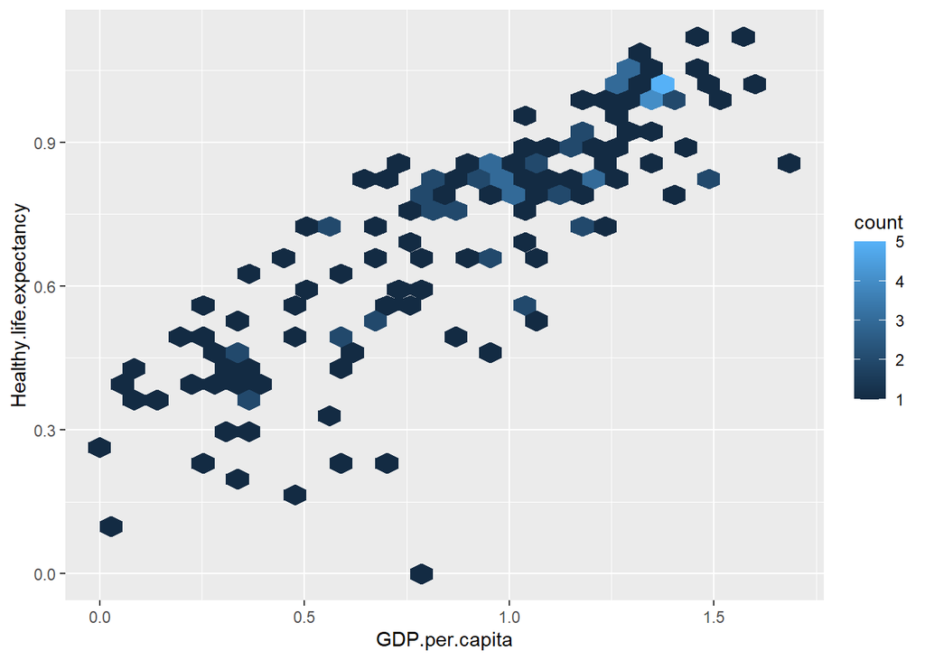

W krajach o dużym PKB w teorii długość życia powinna być ważnym czynnikiem wpływającym na zadowolenie, ponieważ oznaczałoby to, że pieniądze te są inwestowane również w bezpieczeństwo, czy zdrowie mieszkańców. Okazuje się, że faktycznie stanowcza większość krajów o wyższym PKB ma również duże wartości w oczekiwanej długości życia.

## 4.2 PKB, a wynik ogólnego zadowolenia

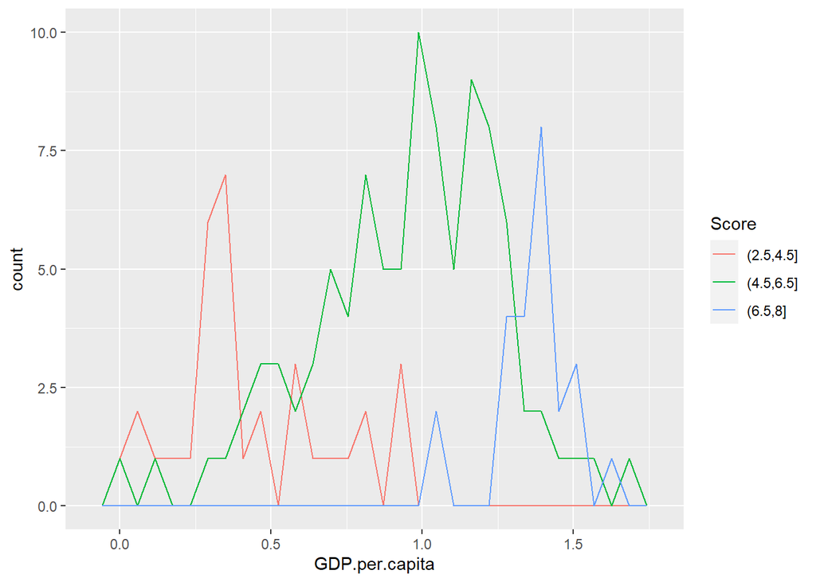

PKB na mieszkańca powinno wpływać na zamożność kraju, a co za tym idzie na komfort i zadowolenie jego mieszkańców. Dzięki przeprowadzonym ankietom faktycznie można zauważyć taką zależność. Kraje o największym poziomie zadowolenia stanowią znaczącą większość spośród tych, które mają największe PKB na mieszkańca. Natomiast kraje z zakresu wyniku od 4.5 do 6.5, których jest zdecydowanie najwięcej zajmują środkowe wyniki pod względem PKB.

## 4.3 Szczodrość, a opieka socjalna

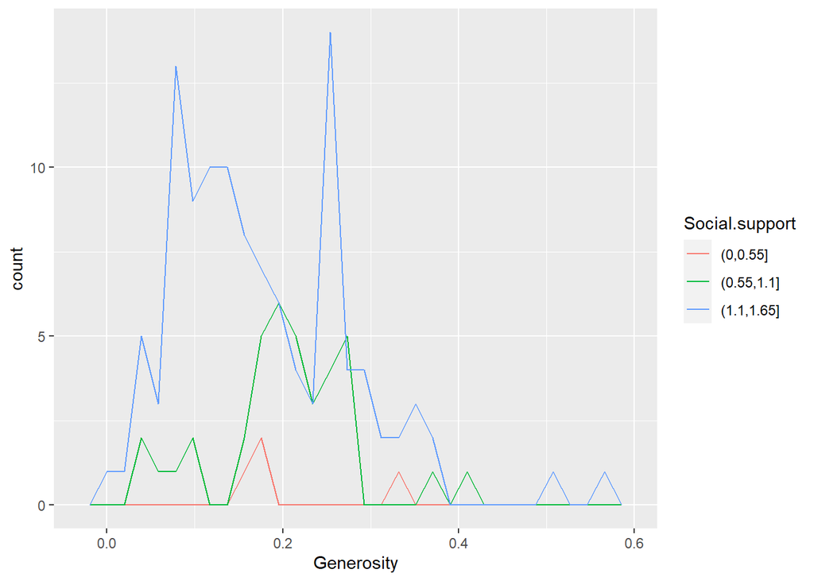

Ogólnie można zauważyć, że szczdrość w danym kraju nie jest jedną z najbardziej zadowalających ludzi rzeczy, natomiast z analizy pojedyńczych zmiennych okazało się, że opieka socjalna często wpływa pozytywnie na zadowolenie. Kiedy porównamy ze sobą te dane okazuje się, że opieka socjalna największym wpływem na zadowolenie cieszy się w krajach o przeciętnej szczodrości.